# Day 5 - Science, art, or somewhere inbetween

# Objectives

- Define Tufte’s theory of data graphics, data-ink ratio, and chartjunk
- Present and compare examples of minimalistic graphics to their original form
- Assess visualizations under the engineer/designers philosophy

```r
library(tidyverse)
library(ggthemes)
library(knitr)
library(broom)
library(stringr)

options(digits = 3)
set.seed(1234)
```

# Tufte’s world

- Core purpose of visualization is to communicate quantitative information
  - Art is secondary
  - “Above all else show the data”
- Goal is to maximize the data-ink ratio

  $$\text{Data-ink ratio} = \frac{\text{data-ink}}{\text{total ink used to print the graphic}}$$
- **Data-ink** - non-erasable core of a graphic
  - This is what Tufte says we should most care about
  - Minimize all extraneous fluff
- What should we consider to be part of the “data-ink”?
  - Is this literally just the data? Don’t we need gridlines or axes? What else can be considered integral to the graph?
- He never offers proof of his hypothesis that less is better

## Chart junk

- Vibrating moire effects
  - Hard to produce in `ggplot2` - no support for them
  - Eye junk
  - Makes the graph harder to decode/interpret
- The grid
  - Minimize/reduce the thickness of grid lines to ease interpretation
  - Less visual clutter to weed through
  - Add some compare/contrast with `ggplot`
- The duck
- Tufte concludes that forgoing chartjunk enables functionality and insight (as Cairo would describe it). Do you agree?

# Compare Tufte minimal graphs to traditional graphs using `ggplot2`

- [`ggthemes`](https://github.com/jrnold/ggthemes)
- Compare other themes for the same basic plot[^1]

The goal of Tufte’s minimalism is to maximize the data-ink ratio, so we want to modify traditional or default graphs in R and `ggplot2` to minimize use of extraneous ink.

## Minimal line plot

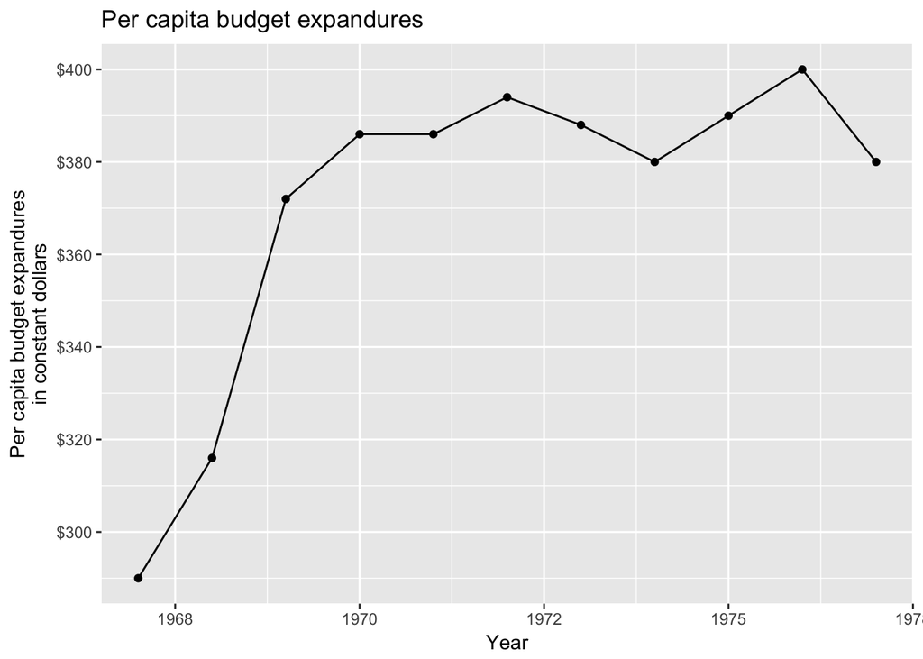

```r
x <- 1967:1977
y <- c(0.5, 1.8, 4.6, 5.3, 5.3, 5.7, 5.4, 5, 5.5, 6, 5)
d <- data_frame(x, y)

ggplot(d, aes(x, y)) +
  geom_line() +
  geom_point() +
  scale_y_continuous(breaks = seq(1, 6, 1), label = sprintf("$%s", seq(300, 400, 20))) +
  labs(title = "Per capita budget expandures",
       x = "Year",
       y = "Per capita budget expandures\nin constant dollars")
```

- We use `geom_point()` to draw the data points and `geom_line()` to connect the points
- What is the extraneous ink on this graph?
  - Background
  - Title of graph and y-axis labels - redundant
  - x-axis label - year is obvious/self-explanatory
- Missing context - how is this expansion meaningful over time?

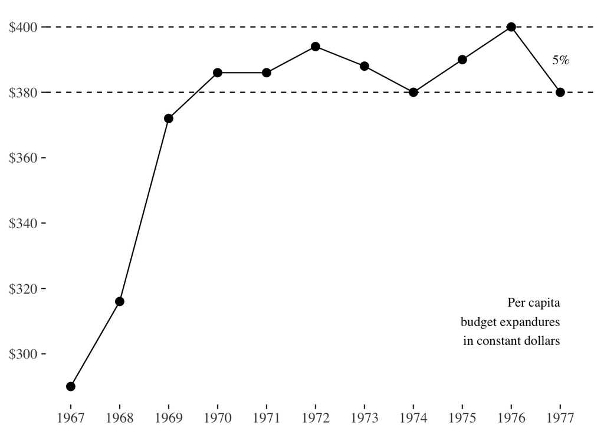

```r
ggplot(d, aes(x, y)) +
  geom_line() +
  geom_point(size = 3) +
  theme_tufte(base_size = 15) +
  theme(axis.title = element_blank()) +
  geom_hline(yintercept = c(5, 6), lty = 2) +
  scale_y_continuous(breaks = seq(1, 6, 1), label = sprintf("$%s", seq(300, 400, 20))) +
  scale_x_continuous(breaks = x, label = x) +
  annotate(
    "text",
    x = c(1977, 1977.2),
    y = c(1.5, 5.5),
    adj = 1,
    family = "serif",
    label = c("Per capita\nbudget expandures\nin constant dollars", "5%")
  )
```

- Remove axis and graph titles
- Adds text annotation within graph
- Highlights a 5% increase in per capital expandures
- Changes font to be more aesthetically pleasing, not so blockish

## Minimal boxplot

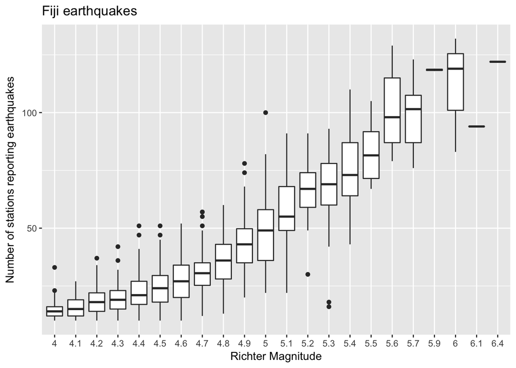

```r
ggplot(quakes, aes(factor(mag), stations)) +
  geom_boxplot() +
  labs(title = "Fiji earthquakes",
       x = "Richter Magnitude",
       y = "Number of stations reporting earthquakes")
```

- Key features of a boxplot
  - Lines to indicate:
    - Maximum of IQR
    - 3rd quartile
    - Median
    - 1st quartile
    - Minimum of IQR
  - Dots for outliers
- How many different line strokes do we use?
  - 8 for each graph
  - $8 \times 22 = 176$
- This is extraneous ink

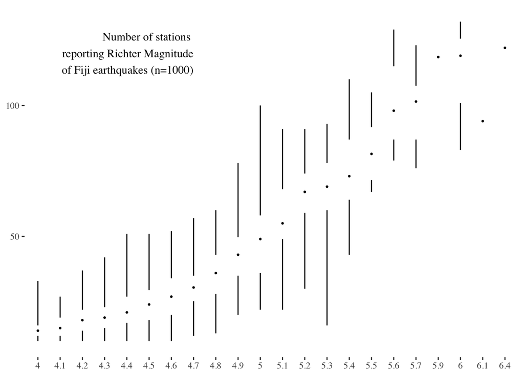

```r
ggplot(quakes, aes(factor(mag), stations)) +
  theme_tufte() +
  geom_tufteboxplot(outlier.colour = "transparent") +
  theme(axis.title = element_blank()) +
  annotate(
    "text",
    x = 8,
    y = 120,
    adj = 1,
    family = "serif",
    label = c(
      "Number of stations \nreporting Richter Magnitude\nof Fiji earthquakes (n=1000)"
    )
  )
```

- Now we use only 22 verticals to show the same data. It could easily be drawn by hand with a single vertical for each category on the x-axis
- Doesn’t show outlier info, but is this really necessary?
- Also removes the background color and gridlines

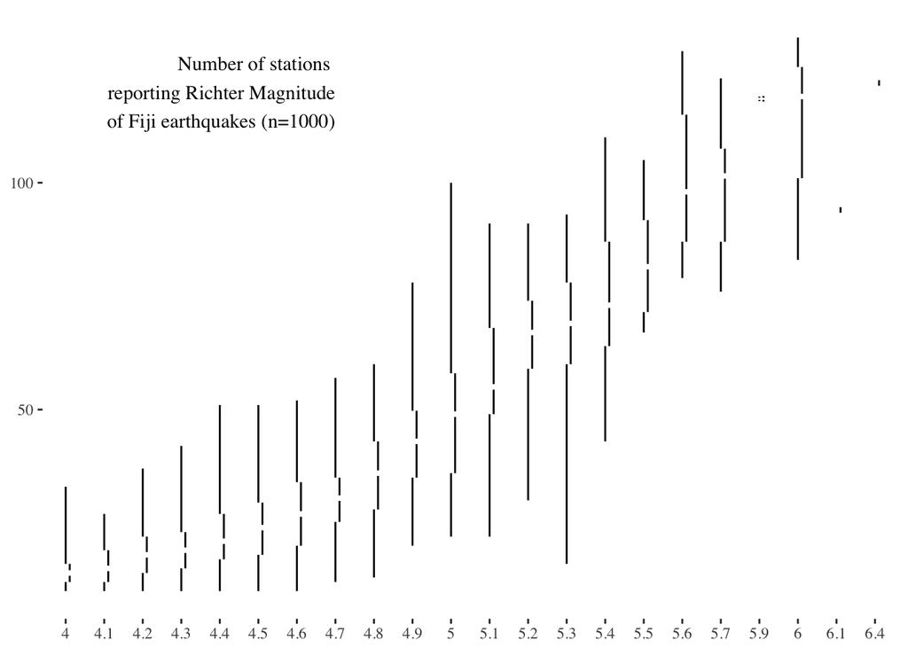

```r
ggplot(quakes, aes(factor(mag), stations)) +
  theme_tufte() +
  geom_tufteboxplot(median.type = "line") +
  theme(axis.title = element_blank()) +
  annotate(
    "text",
    x = 8,
    y = 120,
    adj = 1,
    family = "serif",
    label = c(
      "Number of stations \nreporting Richter Magnitude\nof Fiji earthquakes (n=1000)"
    )
  )
```

- Here we use offsetting lines to indicate the middle half of the data rather than using a gap
- Is this prettier? Easier to interpret?

## Minimal barchart

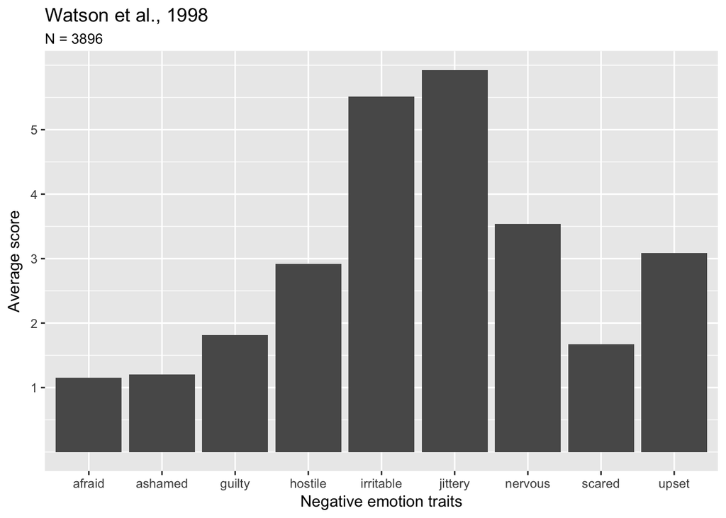

```r
library(psych)
library(reshape2)

d <- melt(colMeans(msq[, c(2, 7, 34, 36, 42, 43, 46, 55, 68)], na.rm = T) *
            10)
d$trait <- rownames(d)

p <- ggplot(d, aes(x = trait, y = value)) +
  geom_bar(stat = "identity") +
  scale_y_continuous(breaks = seq(1, 5, 1)) +
  labs(title = "Watson et al., 1998",
       subtitle = "N = 3896",
       x = "Negative emotion traits",
       y = "Average score")
p
```

- Again, the background is the main culprit - though `ggplot2` offers other default backgrounds

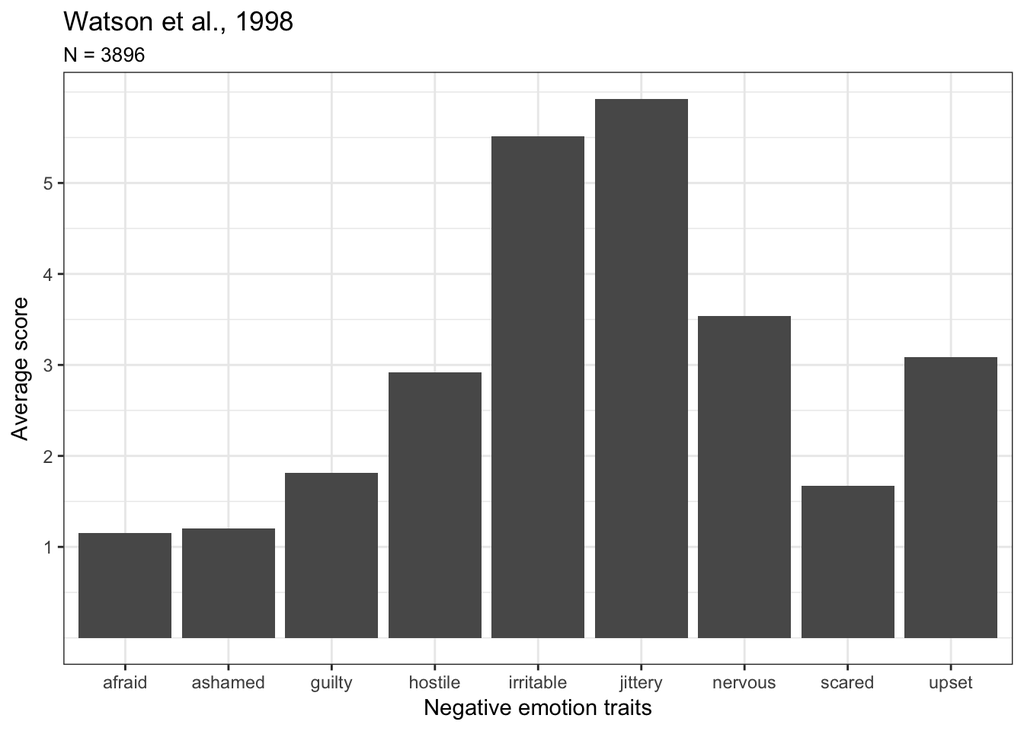

```r
p + theme_bw()
```

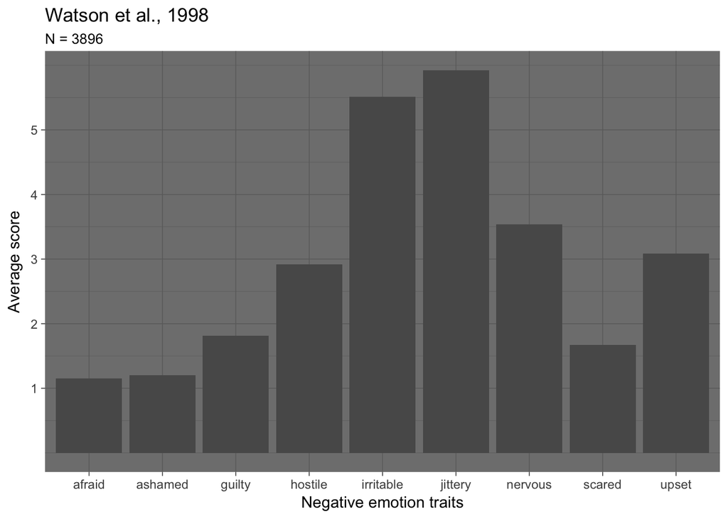

```r
p + theme_dark()
```

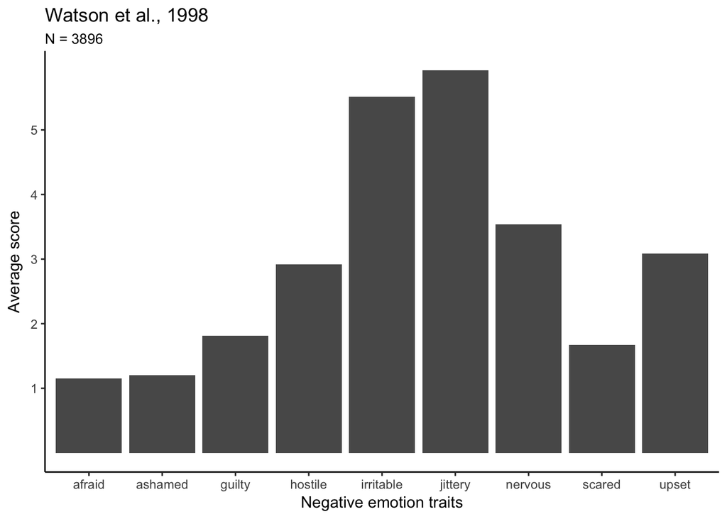

```r
p + theme_classic()
```

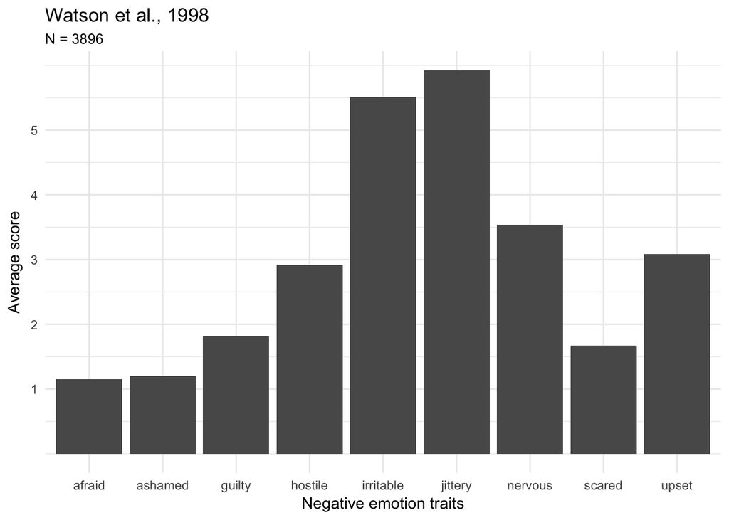

```r
p + theme_minimal()
```

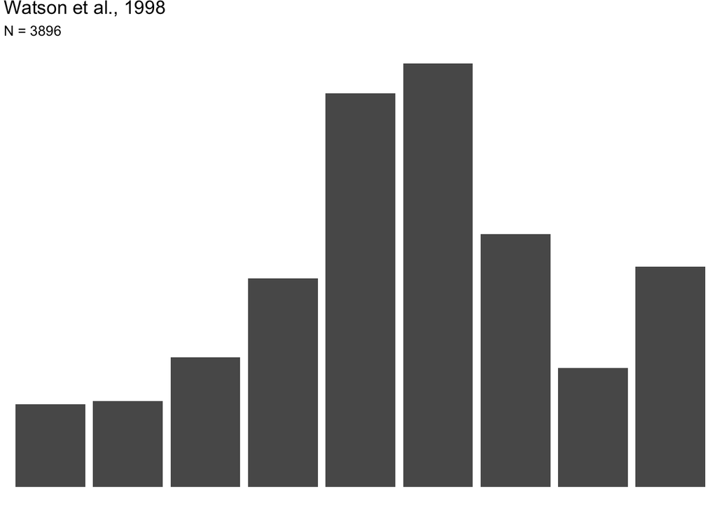

```r
p + theme_void()
```

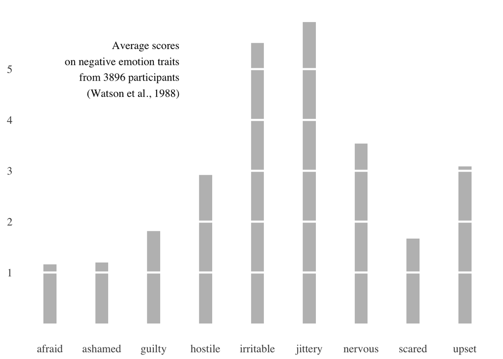

```r
ggplot(d, aes(x = trait, y = value)) +
  theme_tufte(base_size = 14, ticks = F) +
  geom_bar(width = 0.25, fill = "gray", stat = "identity") +
  theme(axis.title = element_blank()) +
  scale_y_continuous(breaks = seq(1, 5, 1)) +
  geom_hline(yintercept = seq(1, 5, 1),
             col = "white",
             lwd = 1) +
  annotate(
    "text",
    x = 3.5,
    y = 5,
    adj = 1,
    family = "serif",
    label = c(
      "Average scores\non negative emotion traits
from 3896 participants\n(Watson et al., 1988)"
    )
  )
```

- Erases the box/grid background
- Removes vertical axis
- Use a **white grid** to show coordinate lines through the absence of ink, rather than adding ink
  - Allows us to remove tick marks as well

## Range-frame scatterplot

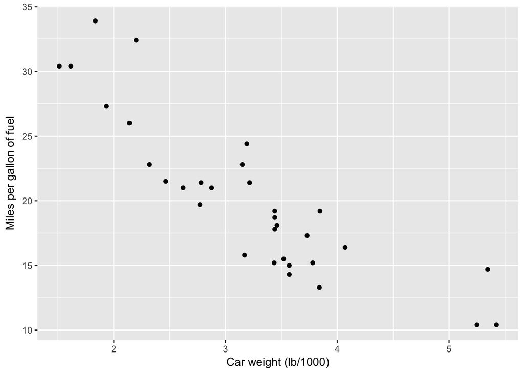

```r
ggplot(mtcars, aes(wt, mpg)) +
  geom_point() +
  xlab("Car weight (lb/1000)") +
  ylab("Miles per gallon of fuel")
```

- A standard bivariate scatterplot

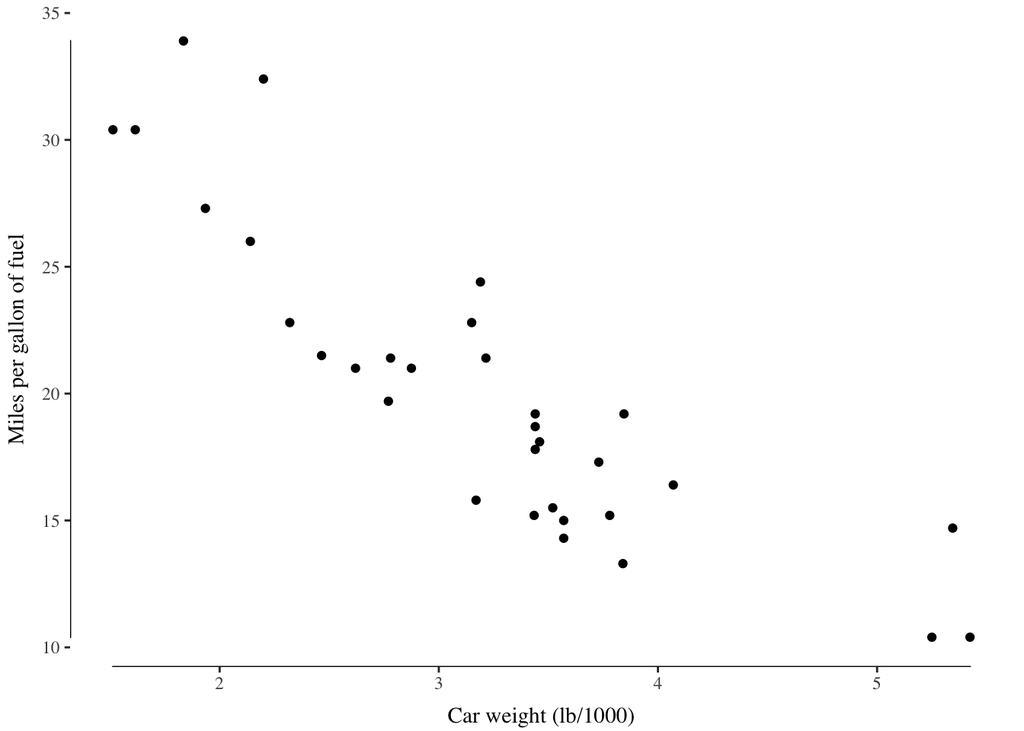

```r
ggplot(mtcars, aes(wt, mpg)) +
  geom_point() +
  geom_rangeframe() +
  theme_tufte() +
  xlab("Car weight (lb/1000)") +
  ylab("Miles per gallon of fuel") +
  theme(axis.title.x = element_text(vjust = -0.5),
        axis.title.y = element_text(vjust = 1.5))
```

- Use the frame/axis lines of the graph to communicate important information
  - Extends only to minimum/maximum values in the data, rather than arbitrary points
  - Explicitly identifies the minimum and maximum values

### With a quartile plot

```r
library(devtools)
source_url('https://raw.githubusercontent.com/bearloga/Quartile-frame-Scatterplot/master/qfplot.R')
```

```
## SHA-1 hash of file is fe88d63ea7111be1a61ea5d36df1bb9c196fba73
```

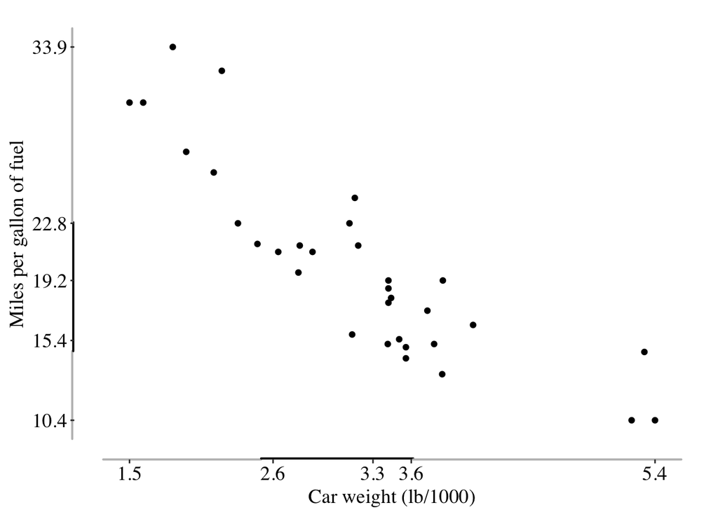

```r
qfplot(
  x = mtcars$wt,
  y = mtcars$mpg,
  xlab = "Car weight (lb/1000)",
  ylab = "Miles per gallon of fuel"
)
```

- Combine with info on the quartiles of the data to show case this info as well
- Thicker bar indicates inner two quartiles
- Median is explicitly labeled

# Reconsidering Tufte

## When is redundancy better?

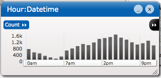

Traditional bar chart of crime in the city of San Francisco, 2009-10. Source: [Visualizing Time with the Double-Time Bar Chart](http://dougmccune.com/blog/2011/04/26/visualizing-time-with-the-double-time-bar-chart/)

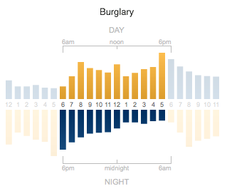

Double-time bar chart of crime in the city of San Francisco, 2009-10. Source: [Visualizing Time with the Double-Time Bar Chart](http://dougmccune.com/blog/2011/04/26/visualizing-time-with-the-double-time-bar-chart/)

- Each set of 24 bars show the same data. The top bars run from midnight to 11pm. The bottom bars run from noon to 11am.
- Highlighted regions represent 6-5 (6am-5pm; 6pm-5am)
- Colors represent (roughly) day and night (yellow for day, blue for night)
- Enables representing trends over a 24 hour period without breaking arbitrarily at midnight
- The second graph is incredibly redundant, but which is easier to interpret?
  - Does it pass Tufte’s test?
  - What does it mean to be “integral”?

## Does minimalism really help here?

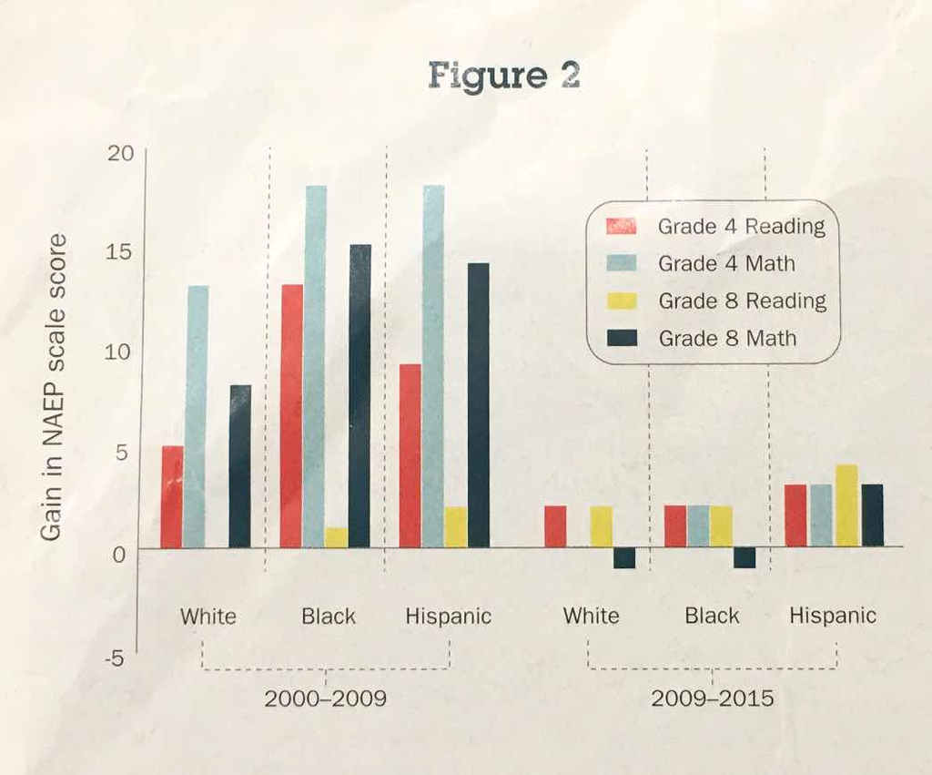

Chart from Harvard magazine. Source: [Involuntary head-shaking is probably not an intended consequence of data visualization](http://junkcharts.typepad.com/junk_charts/2016/11/involuntary-head-shaking-is-probably-not-an-intended-consequence-of-data-visualization.html)

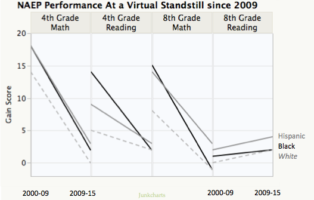

Redesigned chart from Harvard magazine. Source: [Involuntary head-shaking is probably not an intended consequence of data visualization](http://junkcharts.typepad.com/junk_charts/2016/11/involuntary-head-shaking-is-probably-not-an-intended-consequence-of-data-visualization.html)

## Rethinking Tufte’s definition of visual excellence

- Too many of Tufte’s claims are based on nothing - no evidence to support his minimalistic approach to graphical design
- Think of the hockey stick chart vs. xkcd on Earth’s temperature
  - According to Tufte, both probably have a lot of chartjunk (xkcd more so)
  - But if asked to remember the importance and story of the graph weeks later, whcih one do you think the average reader would recall better?

# Statistical graphics vs infographics

## Different goals

### Statistical graphics

- Facilitate an understanding of problems in an applied problem
- Direct readers to specific information
- Allow readers to see for themselves

### Infographics

- Attractive
- Grab one’s attention
- Tell a story
- Encourage viewer to think about a particular dataset

## Assessing the visualization

### Wordles/wordclouds

```r
library(twitteR)
library(tidytext)

# setup API authentication
setup_twitter_oauth(getOption("twitter_api_key"),
                    getOption("twitter_api_token"))
```

```
## [1] "Using browser based authentication"
```

```r
# get fresh trump tweets
trump <- userTimeline("realDonaldTrump", n = 3200) %>%
  twListToDF %>%
  as_tibble

reg <- "([^A-Za-z\\d#@']|'(?![A-Za-z\\d#@]))"   # custom regular expression to tokenize tweets

# tokenize
trump_token <- trump %>%
  filter(!str_detect(text, '^"')) %>%
  mutate(text = str_replace_all(text, "https://t.co/[A-Za-z\\d]+|&amp;", "")) %>%
  unnest_tokens(word, text, token = "regex", pattern = reg) %>%
  filter(!word %in% stop_words$word,
         str_detect(word, "[a-z]"))
```

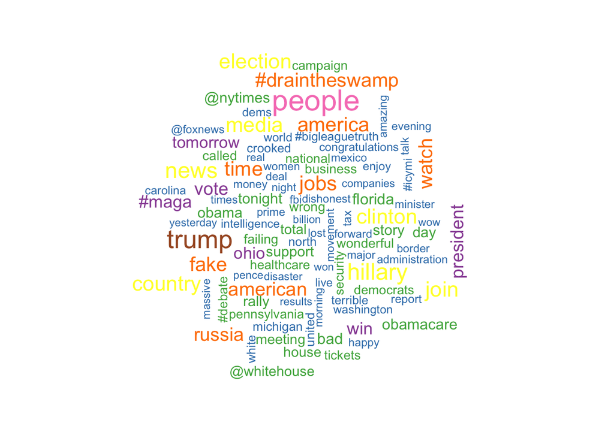

```r
library(wordcloud)
library(RColorBrewer)

pal <- brewer.pal(8, "Set1")

trump_token %>%
  count(word) %>%
  with(wordcloud(word, n, max.words = 100, scale = c(2,.5),
       colors = pal))
```

- What does this graph do well?
- How does it advance the goals (or not) of Tufte/Gelman/Unwin?
- How does it advance the goals (or not) of Nigel Holmes?

### Decision tree: the Obama-Clinton divide

[figure not shown]

- What does this graph do well?
- How does it advance the goals (or not) of Tufte/Gelman/Unwin?
- How does it advance the goals (or not) of Nigel Holmes?

### Health-care spending and life expectancy

- [Original](http://www.oliveruberti.com/infographics/ewpc0ylkniugxuu1gm8o0zy8f4jvft)
- Revised

[figure not shown]

- What are the advantages/disadvantages to the first plot?
- What are the advantages/disadvantages to the second plot?

[output not shown]

```
## Packages ------------------------------------------------------------------
```

[output not shown]

[output cut: 9 more lines]

[output not shown]

[^1]: Source for examples: [Tufte in R](http://motioninsocial.com/tufte/)